# R for Data Science

홍우헌

quasar103@naver.com

2018-07-29

> Part 2  
> Wrangle(2)

# 1 Chapter 9 : Tidy Data with tidyr

1. Each variable must have its own column.
2. Each observation must have its own row.
3. Each value must have its own cell.

tidy data의 이점

- 데이터 저장의 일관성 있는 방법으로의 이점이 있다. 균일성 때문에 툴을 학습하기 좋다
- R의 벡터화된 환경 때문에 열에 변수를 위치시키는 이점

## 1.1 Spreading and Gathering

대부분의 데이터가 tidy가 아닌 이유

- 대부분의 사람들은 tidy 데이터에 친숙하지 않고 데이터 작업에 많은 시간을 투자하지 않는다면 자기 자신으로부터 얻기 어렵다
- 데이터는 종종 분석을 제외하고 몇가지 사용을 용이하게 하기 위해 구성된다. 예를 들어, 데이터는 종종 가능한한 쉽게 entry 구성

첫번째 단계는 변수와 관측치를 구별하는 것이고, 두번째는 데이터를 만든 사람으로부터 상담하는 것이다. 두번째 방법에는 두가지 흔한 문제가 있는데, (1) 하나의 변수가 다수의 변수에 걸쳐서 있다. (2) 하나의 관측가 다수의 행에 걸쳐서 있다.

## 1.2 Exercises

1. Why are gather() and spread() not perfectly symmetrical? Carefully consider the following example:

```r
stocks <- tibble(
  year = c(2015, 2015, 2016, 2016),
  half = c( 1, 2, 1, 2),
  return = c(1.88, 0.59, 0.92, 0.17)
)
stocks %>%
  spread(year, return) %>%
  gather("year", "return", `2015`:`2016`, convert = TRUE)
```

```
## # A tibble: 4 x 3
##    half  year return
##   <dbl> <int>  <dbl>
## 1     1  2015   1.88
## 2     2  2015   0.59
## 3     1  2016   0.92
## 4     2  2016   0.17
```

(Hint: look at the variable types and think about column names.) Both spread() and gather() have a convert argument. What does it do?

2. Why does this code fail?

```r
table4a %>%
  gather(`1999`, `2000`, key = "year", value = "cases")
```

```
## # A tibble: 6 x 3
##   country     year   cases
##   <chr>       <chr>  <int>
## 1 Afghanistan 1999     745
## 2 Brazil      1999   37737
## 3 China       1999  212258
## 4 Afghanistan 2000    2666
## 5 Brazil      2000   80488
## 6 China       2000  213766
```

이 문제는 기억해두자. 3. Why does spreading this tibble fail? How could you add a new column to fix the problem?

```r
people <- tribble(
  ~name, ~key, ~value,
  #-----------------|--------|------
  "Phillip Woods", "age", 45,
  "Phillip Woods", "height", 186,
  "Phillip Woods", "age", 50,
  "Jessica Cordero", "age", 37,
  "Jessica Cordero", "height", 156
)

spread(people, key, value)
```

```
## Error: Duplicate identifiers for rows (1, 3)
```

```r
people <- tribble(
  ~name,             ~key,    ~value, ~obs,
  #-----------------|--------|------|------
  "Phillip Woods",   "age",       45, 1,
  "Phillip Woods",   "height",   186, 1,
  "Phillip Woods",   "age",       50, 2,
  "Jessica Cordero", "age",       37, 1,
  "Jessica Cordero", "height",   156, 1
)

spread(people, key, value)
```

```
## # A tibble: 3 x 4
##   name              obs   age height
##   <chr>           <dbl> <dbl>  <dbl>
## 1 Jessica Cordero     1    37    156
## 2 Phillip Woods       1    45    186
## 3 Phillip Woods       2    50     NA
```

4. Tidy this simple tibble. Do you need to spread or gather it? What are the variables?

```r
preg <- tribble(
  ~pregnant, ~male, ~female,
  "yes", NA, 10,
  "no", 20, 12
)
```

```r
gather(preg, sex, count, -1) %>%
  mutate(pregnant = pregnant == "yes",
         male = sex == "male") %>%
  select(-sex)
```

```
## # A tibble: 4 x 3
##   pregnant count male
##   <lgl>    <dbl> <lgl>
## 1 TRUE        NA TRUE
## 2 FALSE       20 TRUE
## 3 TRUE        10 FALSE
## 4 FALSE       12 FALSE
```

## 1.3 Separating and Pull

### 1.3.1 Separate

separate의 sep인자의 디폴트는 알파벳 값이 아닌 정규표현식 convert를 설정하지 않으면 원래의 데이터 타입을 따른다.

```r
table3
```

```
## # A tibble: 6 x 3
##   country      year rate
## * <chr>       <int> <chr>
## 1 Afghanistan  1999 745/19987071
## 2 Afghanistan  2000 2666/20595360
## 3 Brazil       1999 37737/172006362
## 4 Brazil       2000 80488/174504898
## 5 China        1999 212258/1272915272
## 6 China        2000 213766/1280428583
```

```r
separate(table3, rate, into = c("cases", "pop"), convert = TRUE)
```

```
## # A tibble: 6 x 4
##   country      year  cases        pop
## * <chr>       <int>  <int>      <int>
## 1 Afghanistan  1999    745   19987071
## 2 Afghanistan  2000   2666   20595360
## 3 Brazil       1999  37737  172006362
## 4 Brazil       2000  80488  174504898
## 5 China        1999 212258 1272915272
## 6 China        2000 213766 1280428583
```

sep.separate()는 정수의 위치를 나눈다. 1은 문자열의 왼쪽으로부터 떨어진 정도, -1은 문자열의 오른쪽으로부터의 떨어진 정도

```r
separate(table3, year, into = c("century", "year"), sep = 2)
```

```
## # A tibble: 6 x 4
##   country     century year  rate
## * <chr>       <chr>   <chr> <chr>
## 1 Afghanistan 19      99    745/19987071
## 2 Afghanistan 20      00    2666/20595360
## 3 Brazil      19      99    37737/172006362
## 4 Brazil      20      00    80488/174504898
## 5 China       19      99    212258/1272915272
## 6 China       20      00    213766/1280428583
```

### 1.3.2 Unite

unite()는 separate()의 역함수다. 다수의 열을 하나의 열로 조합시킨다. sep의 디폴트는 “_“이다.

```r
table5 %>%
  unite(new, century, year, sep = "")
```

```
## # A tibble: 6 x 3
##   country     new   rate
##   <chr>       <chr> <chr>
## 1 Afghanistan 1999  745/19987071
## 2 Afghanistan 2000  2666/20595360
## 3 Brazil      1999  37737/172006362
## 4 Brazil      2000  80488/174504898
## 5 China       1999  212258/1272915272
## 6 China       2000  213766/1280428583
```

## 1.4 Exercises

1. What do the extra and fill arguments do in separate()? Experiment with the various options for the following two toy datasets:

extra  
If sep is a character vector, this controls what happens when there are too many pieces. There are three valid options:

“warn” (the default): emit a warning and drop extra values.

“drop”: drop any extra values without a warning.

“merge”: only splits at most length(into) times

fill  
If sep is a character vector, this controls what happens when there are not enough pieces. There are three valid options:

“warn” (the default): emit a warning and fill from the right

“right”: fill with missing values on the right

“left”: fill with missing values on the left

```r
tibble(x = c("a,b,c", "d,e,f,g", "h,i,j")) %>%
  separate(x, c("one", "two", "three"), extra = "merge")
```

```
## # A tibble: 3 x 3
##   one   two   three
##   <chr> <chr> <chr>
## 1 a     b     c
## 2 d     e     f,g
## 3 h     i     j
```

```r
tibble(x = c("a,b,c", "d,e", "f,g,i")) %>%
  separate(x, c("one", "two", "three"), fill = "left")
```

```
## # A tibble: 3 x 3
##   one   two   three
##   <chr> <chr> <chr>
## 1 a     b     c
## 2 <NA>  d     e
## 3 f     g     i
```

2. Both unite() and separate() have a remove argument. What does it do? Why would you set it to FALSE?

remove = FALSE : 원래 df를 제거하지 않는다.

```r
tibble(x = c("a,b,c", "d,e,f,g", "h,i,j")) %>%
  separate(x, c("one", "two", "three"), remove = FALSE)
```

```
## # A tibble: 3 x 4
##   x       one   two   three
##   <chr>   <chr> <chr> <chr>
## 1 a,b,c   a     b     c
## 2 d,e,f,g d     e     f
## 3 h,i,j   h     i     j
```

3. Compare and contrast separate() and extract(). Why are there three variations of separation (by position, by separator, and with groups), but only one unite?

문자열을 합치는 방법은 하나지만 나누는 방법은 많기 때문이다.

```r
df <- data.frame(x = c(NA, "a-b", "a-d", "b-c", "d-e"))
df %>% extract(x, c("A", "B"), "([[:alnum:]]+)-([[:alnum:]]+)")
```

```
##      A    B
## 1 <NA> <NA>
## 2    a    b
## 3    a    d
## 4    b    c
## 5    d    e
```

## 1.5 Missing Values

결측치는 NA로 명시될 수도 있지만 아닐 수도 있다.

```r
stocks <- tibble(
  year = c(2015, 2015, 2015, 2015, 2016, 2016, 2016),
  qtr = c( 1, 2, 3, 4, 2, 3, 4),
  return = c(1.88, 0.59, 0.35, NA, 0.92, 0.17, 2.66)
)
```

4번째 행에 NA가 있고, 2016년 1분기 데이터가 없으므로 이 데이터 셋은 두 개의 결측치가 있다.

암시적인 결측값을 분명히 해준다.

```r
stocks %>%
  spread(year, return)
```

```
## # A tibble: 4 x 3
##     qtr `2015` `2016`
##   <dbl>  <dbl>  <dbl>
## 1     1   1.88  NA
## 2     2   0.59   0.92
## 3     3   0.35   0.17
## 4     4  NA      2.66
```

이러한 명백한 결측값들이 중요하지 않기 때문에,

```r
stocks %>%
  spread(year, return) %>%
  gather(year, return, `2015`:`2016`, na.rm = TRUE)
```

```
## # A tibble: 6 x 3
##     qtr year  return
## * <dbl> <chr>  <dbl>
## 1     1 2015    1.88
## 2     2 2015    0.59
## 3     3 2015    0.35
## 4     2 2016    0.92
## 5     3 2016    0.17
## 6     4 2016    2.66
```

결측 값을 분명히 해주는 다른 함수는 `complete()`

```r
stocks %>%
  complete(year, qtr)
```

```
## # A tibble: 8 x 3
##    year   qtr return
##   <dbl> <dbl>  <dbl>
## 1  2015     1   1.88
## 2  2015     2   0.59
## 3  2015     3   0.35
## 4  2015     4  NA
## 5  2016     1  NA
## 6  2016     2   0.92
## 7  2016     3   0.17
## 8  2016     4   2.66
```

complete()은 열을 취하고 모든 유일한 조합을 찾는다. 이 함수는 원래의 데이터셋이 모든 명백하게 필요한 NA를 채우도록 포함시킨다.

```r
treatment <- tribble(
  ~ person, ~ treatment, ~response,
  "Derrick Whitmore", 1, 7,
  NA, 2, 10,
  NA, 3, 9,
  "Katherine Burke", 1, 4
)
```

`fill()`은 가장 최근의 결측치가 아닌 값으로 대체한다.

```r
treatment %>%
  fill(person)
```

```
## # A tibble: 4 x 3
##   person           treatment response
##   <chr>                <dbl>    <dbl>
## 1 Derrick Whitmore         1        7
## 2 Derrick Whitmore         2       10
## 3 Derrick Whitmore         3        9
## 4 Katherine Burke          1        4
```

## 1.6 Exercises

1. Compare and contrast the fill arguments to spread() and com plete().

```r
stocks %>%
  spread(year, return, fill = "1")
```

```
## # A tibble: 4 x 3
##     qtr `2015` `2016`
##   <dbl> <chr>  <chr>
## 1     1 1.88   1
## 2     2 0.59   0.92
## 3     3 0.35   0.17
## 4     4 1      2.66
```

```r
stocks %>%
  complete(year, qtr, fill = list(return = "haha"))
```

```
## # A tibble: 8 x 3
##    year   qtr return
##   <dbl> <dbl> <chr>
## 1  2015     1 1.88
## 2  2015     2 0.59
## 3  2015     3 0.35
## 4  2015     4 haha
## 5  2016     1 haha
## 6  2016     2 0.92
## 7  2016     3 0.17
## 8  2016     4 2.66
```

2. What does the direction argument to fill() do?

```r
df <- data.frame(Month = 1:12, Year = c(rep(NA, 11), 2000))
df %>% fill(Year, .direction = "up")
```

```
##    Month Year
## 1      1 2000
## 2      2 2000
## 3      3 2000
## 4      4 2000
## 5      5 2000
## 6      6 2000
## 7      7 2000
## 8      8 2000
## 9      9 2000
## 10    10 2000
## 11    11 2000
## 12    12 2000
```

## 1.7 Case Study

tuberculosis(TB)결핵 데이터이다.

```r
who
```

```
## # A tibble: 7,240 x 60
##    country iso2  iso3   year new_sp_m014 new_sp_m1524 new_sp_m2534
##    <chr>   <chr> <chr> <int>       <int>        <int>        <int>
##  1 Afghan~ AF    AFG    1980          NA           NA           NA
##  2 Afghan~ AF    AFG    1981          NA           NA           NA
##  3 Afghan~ AF    AFG    1982          NA           NA           NA
##  4 Afghan~ AF    AFG    1983          NA           NA           NA
##  5 Afghan~ AF    AFG    1984          NA           NA           NA
##  6 Afghan~ AF    AFG    1985          NA           NA           NA
##  7 Afghan~ AF    AFG    1986          NA           NA           NA
##  8 Afghan~ AF    AFG    1987          NA           NA           NA
##  9 Afghan~ AF    AFG    1988          NA           NA           NA
## 10 Afghan~ AF    AFG    1989          NA           NA           NA
## # ... with 7,230 more rows, and 53 more variables: new_sp_m3544 <int>,
## #   new_sp_m4554 <int>, new_sp_m5564 <int>, new_sp_m65 <int>,
## #   new_sp_f014 <int>, new_sp_f1524 <int>, new_sp_f2534 <int>,
## #   new_sp_f3544 <int>, new_sp_f4554 <int>, new_sp_f5564 <int>,
## #   new_sp_f65 <int>, new_sn_m014 <int>, new_sn_m1524 <int>,
## #   new_sn_m2534 <int>, new_sn_m3544 <int>, new_sn_m4554 <int>,
## #   new_sn_m5564 <int>, new_sn_m65 <int>, new_sn_f014 <int>,
## #   new_sn_f1524 <int>, new_sn_f2534 <int>, new_sn_f3544 <int>,
## #   new_sn_f4554 <int>, new_sn_f5564 <int>, new_sn_f65 <int>,
## #   new_ep_m014 <int>, new_ep_m1524 <int>, new_ep_m2534 <int>,
## #   new_ep_m3544 <int>, new_ep_m4554 <int>, new_ep_m5564 <int>,
## #   new_ep_m65 <int>, new_ep_f014 <int>, new_ep_f1524 <int>,
## #   new_ep_f2534 <int>, new_ep_f3544 <int>, new_ep_f4554 <int>,
## #   new_ep_f5564 <int>, new_ep_f65 <int>, newrel_m014 <int>,
## #   newrel_m1524 <int>, newrel_m2534 <int>, newrel_m3544 <int>,
## #   newrel_m4554 <int>, newrel_m5564 <int>, newrel_m65 <int>,
## #   newrel_f014 <int>, newrel_f1524 <int>, newrel_f2534 <int>,
## #   newrel_f3544 <int>, newrel_f4554 <int>, newrel_f5564 <int>,
## #   newrel_f65 <int>
```

불필요한 열들을 포함하고 있고, 이상한 변수 코드가 있으며 많은 결측치들을 포함하고 있다.

가장 좋은 시작점은 변수가 아닌 열들을 함께 모으는 것이다.

- country, iso2, iso3은 국가를 나타내는 불필요한 세개의 변수이다.
- year은 명백하게 변수
- 모든 다른 변수들이 어떤지는 아직 모르지만, 변수들의 구조를 고려하면 변수가 아니라 값 같다.

cell이 case의 수를 나타내므로 case라는 이름의 변수 사용.

```r
who1 <- who %>%
  gather(
    new_sp_m014:newrel_f65, key = "key",
    value = "cases",
    na.rm = TRUE
  )
who1
```

```
## # A tibble: 76,046 x 6
##    country     iso2  iso3   year key         cases
##  * <chr>       <chr> <chr> <int> <chr>       <int>
##  1 Afghanistan AF    AFG    1997 new_sp_m014     0
##  2 Afghanistan AF    AFG    1998 new_sp_m014    30
##  3 Afghanistan AF    AFG    1999 new_sp_m014     8
##  4 Afghanistan AF    AFG    2000 new_sp_m014    52
##  5 Afghanistan AF    AFG    2001 new_sp_m014   129
##  6 Afghanistan AF    AFG    2002 new_sp_m014    90
##  7 Afghanistan AF    AFG    2003 new_sp_m014   127
##  8 Afghanistan AF    AFG    2004 new_sp_m014   139
##  9 Afghanistan AF    AFG    2005 new_sp_m014   151
## 10 Afghanistan AF    AFG    2006 new_sp_m014   193
## # ... with 76,036 more rows
```

새로운 key 변수에서 값의 구조의 힌트를 얻을 수 있다.

```r
who1 %>%
  count(key)
```

```
## # A tibble: 56 x 2
##    key              n
##    <chr>        <int>
##  1 new_ep_f014   1032
##  2 new_ep_f1524  1021
##  3 new_ep_f2534  1021
##  4 new_ep_f3544  1021
##  5 new_ep_f4554  1017
##  6 new_ep_f5564  1017
##  7 new_ep_f65    1014
##  8 new_ep_m014   1038
##  9 new_ep_m1524  1026
## 10 new_ep_m2534  1020
## # ... with 46 more rows
```

1. 각 열의 첫 번째 세글자는 열이 TB의 구, 신 케이스를 포함하고 있는지를 나타낸다. 이 데이터에서는 새로운 케이스를 포함한다.
2. 그 다음 두 글자는 TB의 타입을 나타낸다.
- rel은 relapse(재발)의 케이스를 의미한다.
- ep은 TB의 extrapulmonary(허파바깥)케이스
- sn은 폐 smaer에 의해 진단을 받지않은 폐 케이스(smaer 음성)
- sp은 폐 smear에 의해 진단을 받은 폐 케이스(smear 양성)
3. 6번째 글자는 성별을 의미
4. 나머지 숫자는 나이 그룹을 의미한다.

• 014 = 0–14 years old • 1524 = 15–24 years old • 2534 = 25–34 years old • 3544 = 35–44 years old • 4554 = 45–54 years old • 5564 = 55–64 years old • 65 = 65 or older

일관적이지 않은 이름 수정

```r
who2 <- who1 %>%
  mutate(key = str_replace(key, "newrel", "new_rel"))
who2
```

```
## # A tibble: 76,046 x 6
##    country     iso2  iso3   year key         cases
##    <chr>       <chr> <chr> <int> <chr>       <int>
##  1 Afghanistan AF    AFG    1997 new_sp_m014     0
##  2 Afghanistan AF    AFG    1998 new_sp_m014    30
##  3 Afghanistan AF    AFG    1999 new_sp_m014     8
##  4 Afghanistan AF    AFG    2000 new_sp_m014    52
##  5 Afghanistan AF    AFG    2001 new_sp_m014   129
##  6 Afghanistan AF    AFG    2002 new_sp_m014    90
##  7 Afghanistan AF    AFG    2003 new_sp_m014   127
##  8 Afghanistan AF    AFG    2004 new_sp_m014   139
##  9 Afghanistan AF    AFG    2005 new_sp_m014   151
## 10 Afghanistan AF    AFG    2006 new_sp_m014   193
## # ... with 76,036 more rows
```

변수 이름 분리

```r
who3 <- who2 %>%
  separate(key, c("new", "type", "sexage"), sep = "_")
who3
```

```
## # A tibble: 76,046 x 8
##    country     iso2  iso3   year new   type  sexage cases
##    <chr>       <chr> <chr> <int> <chr> <chr> <chr>  <int>
##  1 Afghanistan AF    AFG    1997 new   sp    m014       0
##  2 Afghanistan AF    AFG    1998 new   sp    m014      30
##  3 Afghanistan AF    AFG    1999 new   sp    m014       8
##  4 Afghanistan AF    AFG    2000 new   sp    m014      52
##  5 Afghanistan AF    AFG    2001 new   sp    m014     129
##  6 Afghanistan AF    AFG    2002 new   sp    m014      90
##  7 Afghanistan AF    AFG    2003 new   sp    m014     127
##  8 Afghanistan AF    AFG    2004 new   sp    m014     139
##  9 Afghanistan AF    AFG    2005 new   sp    m014     151
## 10 Afghanistan AF    AFG    2006 new   sp    m014     193
## # ... with 76,036 more rows
```

불필요한 열 제거

```r
who3 %>%
  count(new) # 모두 new
```

```
## # A tibble: 1 x 2
##   new       n
##   <chr> <int>
## 1 new   76046
```

```r
who4 <- who3 %>%
  select(-new, -iso2, -iso3)
```

sexage를 sex와 age로 나눈다.

```r
who5 <- who4 %>%
  separate(sexage, c("sex", "age"), sep = 1)
who5
```

```
## # A tibble: 76,046 x 6
##    country      year type  sex   age   cases
##    <chr>       <int> <chr> <chr> <chr> <int>
##  1 Afghanistan  1997 sp    m     014       0
##  2 Afghanistan  1998 sp    m     014      30
##  3 Afghanistan  1999 sp    m     014       8
##  4 Afghanistan  2000 sp    m     014      52
##  5 Afghanistan  2001 sp    m     014     129
##  6 Afghanistan  2002 sp    m     014      90
##  7 Afghanistan  2003 sp    m     014     127
##  8 Afghanistan  2004 sp    m     014     139
##  9 Afghanistan  2005 sp    m     014     151
## 10 Afghanistan  2006 sp    m     014     193
## # ... with 76,036 more rows
```

```r
who %>%
  gather(code, value, new_sp_m014:newrel_f65, na.rm = TRUE) %>%
  mutate(
    code = stringr::str_replace(code, "newrel", "new_rel")
  ) %>%
  separate(code, c("new", "var", "sexage")) %>%
  select(-new, -iso2, -iso3) %>%
  separate(sexage, c("sex", "age"), sep = 1)
```

```
## # A tibble: 76,046 x 6
##    country      year var   sex   age   value
##    <chr>       <int> <chr> <chr> <chr> <int>
##  1 Afghanistan  1997 sp    m     014       0
##  2 Afghanistan  1998 sp    m     014      30
##  3 Afghanistan  1999 sp    m     014       8
##  4 Afghanistan  2000 sp    m     014      52
##  5 Afghanistan  2001 sp    m     014     129
##  6 Afghanistan  2002 sp    m     014      90
##  7 Afghanistan  2003 sp    m     014     127
##  8 Afghanistan  2004 sp    m     014     139
##  9 Afghanistan  2005 sp    m     014     151
## 10 Afghanistan  2006 sp    m     014     193
## # ... with 76,036 more rows
```

## 1.8 Exercises

1. In this case study I set na.rm = TRUE just to make it easier to check that we had the correct values. Is this reasonable? Think about how missing values are represented in this dataset. Are there implicit missing values? What’s the difference between an NA and zero?

항상 눈에 보이는 NA말고도 암시적 결측치를 생각 해 보자.

```r
temp <- who %>%
  gather(code, value, new_sp_m014:newrel_f65) %>%
  mutate(
    code = stringr::str_replace(code, "newrel", "new_rel")
  ) %>%
  separate(code, c("new", "var", "sexage")) %>%
  select(-new, -iso2, -iso3) %>%
  separate(sexage, c("sex", "age"), sep = 1)
```

```r
who5 %>% complete(country, year, type, sex, age)
```

```
## # A tibble: 416,976 x 6
##    country      year type  sex   age   cases
##    <chr>       <int> <chr> <chr> <chr> <int>
##  1 Afghanistan  1980 ep    f     014      NA
##  2 Afghanistan  1980 ep    f     1524     NA
##  3 Afghanistan  1980 ep    f     2534     NA
##  4 Afghanistan  1980 ep    f     3544     NA
##  5 Afghanistan  1980 ep    f     4554     NA
##  6 Afghanistan  1980 ep    f     5564     NA
##  7 Afghanistan  1980 ep    f     65       NA
##  8 Afghanistan  1980 ep    m     014      NA
##  9 Afghanistan  1980 ep    m     1524     NA
## 10 Afghanistan  1980 ep    m     2534     NA
## # ... with 416,966 more rows
```

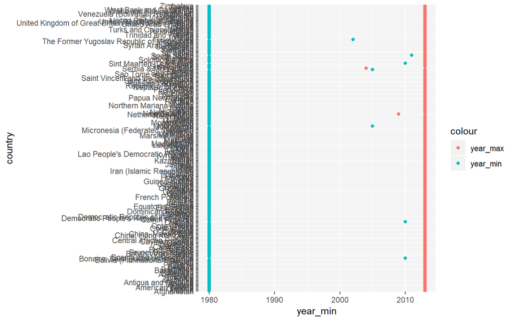

```r
# 결측치를 제거 하지 않았을 때
temp %>%
  group_by(country) %>%
  summarise(year_min = min(year),
            year_max = max(year)) %>%
  ggplot(aes(y = country)) +
    geom_point(aes(x = year_min, colour = "year_min")) +
    geom_point(aes(x = year_max, colour = "year_max"))
```

대부분 1980~2013이지만 아닌 것들도 있다. 즉, implicit 결측치가 있다.

```r
who %>% select(-c(1:4)) %>%
  sapply(function(x){sum(is.na(x))})
```

```
##  new_sp_m014 new_sp_m1524 new_sp_m2534 new_sp_m3544 new_sp_m4554
##         4067         4031         4034         4021         4017
## new_sp_m5564   new_sp_m65  new_sp_f014 new_sp_f1524 new_sp_f2534
##         4022         4031         4066         4046         4040
## new_sp_f3544 new_sp_f4554 new_sp_f5564   new_sp_f65  new_sn_m014
##         4041         4036         4045         4043         6195
## new_sn_m1524 new_sn_m2534 new_sn_m3544 new_sn_m4554 new_sn_m5564
##         6210         6218         6215         6213         6219
##   new_sn_m65  new_sn_f014 new_sn_f1524 new_sn_f2534 new_sn_f3544
##         6220         6200         6218         6224         6220
## new_sn_f4554 new_sn_f5564   new_sn_f65  new_ep_m014 new_ep_m1524
##         6222         6223         6221         6202         6214
## new_ep_m2534 new_ep_m3544 new_ep_m4554 new_ep_m5564   new_ep_m65
##         6220         6216         6220         6225         6222
##  new_ep_f014 new_ep_f1524 new_ep_f2534 new_ep_f3544 new_ep_f4554
##         6208         6219         6219         6219         6223
## new_ep_f5564   new_ep_f65  newrel_m014 newrel_m1524 newrel_m2534
##         6223         6226         7050         7058         7057
## newrel_m3544 newrel_m4554 newrel_m5564   newrel_m65  newrel_f014
##         7056         7056         7055         7058         7050
## newrel_f1524 newrel_f2534 newrel_f3544 newrel_f4554 newrel_f5564
##         7056         7058         7057         7057         7057
##   newrel_f65
##         7055
```

결측치의 패턴을 알 수 없으므로 제거하는것은 타당해 보인다.

2. For each country, year, and sex compute the total number of cases of TB. Make an informative visualization of the data.

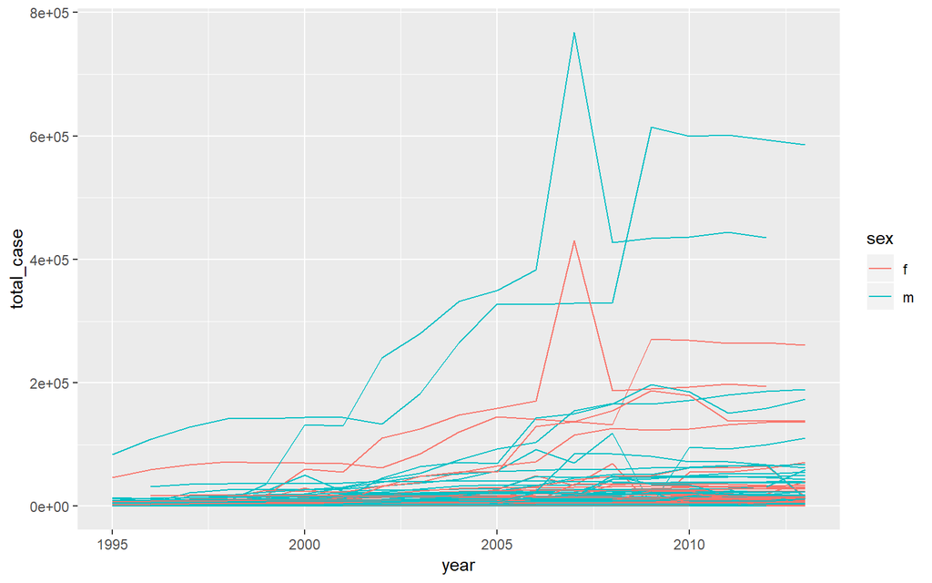

```r
who %>%
  gather(code, value, new_sp_m014:newrel_f65, na.rm = TRUE) %>%
  mutate(code = str_replace(code, "newrel", "new_rel")) %>%
  separate(code, into = c("new", "var", "sexage")) %>%
  select(-new, -iso2, -iso3) %>%
  separate(sexage, into = c("sex", "age"), sep = 1) %>%
  group_by(country, year, sex) %>%
  summarise(total_case = sum(value)) %>%
  unite(country_sex, country, sex, remove = FALSE) %>%
  filter(year >= 1995) %>%
  ggplot() +
  geom_line(aes(year, total_case, color = sex, group = country_sex))
```

country_sex로 합쳐야 선을 구분지을 수 있다.

# 2 Chapter 10 : Relational Data with dplyr

다수 테이블의 데이터는 relational data라고 불린다.

- Mutating joings
- Filtering joins
- Set operations

## 2.1 nycflights13

4개의 tibble 포함

- airlines : 축약된 코드의 이름

```r
airlines
```

```
## # A tibble: 16 x 2
##    carrier name
##    <chr>   <chr>
##  1 9E      Endeavor Air Inc.
##  2 AA      American Airlines Inc.
##  3 AS      Alaska Airlines Inc.
##  4 B6      JetBlue Airways
##  5 DL      Delta Air Lines Inc.
##  6 EV      ExpressJet Airlines Inc.
##  7 F9      Frontier Airlines Inc.
##  8 FL      AirTran Airways Corporation
##  9 HA      Hawaiian Airlines Inc.
## 10 MQ      Envoy Air
## 11 OO      SkyWest Airlines Inc.
## 12 UA      United Air Lines Inc.
## 13 US      US Airways Inc.
## 14 VX      Virgin America
## 15 WN      Southwest Airlines Co.
## 16 YV      Mesa Airlines Inc.
```

- airports : 각 공항의 정보

faa : Federal Aviation Administration

```r
airports
```

```
## # A tibble: 1,458 x 8
##    faa   name                     lat    lon   alt    tz dst   tzone
##    <chr> <chr>                  <dbl>  <dbl> <int> <dbl> <chr> <chr>
##  1 04G   Lansdowne Airport       41.1  -80.6  1044    -5 A     America/New_~
##  2 06A   Moton Field Municipal~  32.5  -85.7   264    -6 A     America/Chic~
##  3 06C   Schaumburg Regional     42.0  -88.1   801    -6 A     America/Chic~
##  4 06N   Randall Airport         41.4  -74.4   523    -5 A     America/New_~
##  5 09J   Jekyll Island Airport   31.1  -81.4    11    -5 A     America/New_~
##  6 0A9   Elizabethton Municipa~  36.4  -82.2  1593    -5 A     America/New_~
##  7 0G6   Williams County Airpo~  41.5  -84.5   730    -5 A     America/New_~
##  8 0G7   Finger Lakes Regional~  42.9  -76.8   492    -5 A     America/New_~
##  9 0P2   Shoestring Aviation A~  39.8  -76.6  1000    -5 U     America/New_~
## 10 0S9   Jefferson County Intl   48.1 -123.    108    -8 A     America/Los_~
## # ... with 1,448 more rows
```

- planes : tailnum으로 식별되는 비행기에 대한 정보

```r
planes
```

```
## # A tibble: 3,322 x 9
##    tailnum  year type       manufacturer   model  engines seats speed engine
##    <chr>   <int> <chr>      <chr>          <chr>    <int> <int> <int> <chr>
##  1 N10156   2004 Fixed win~ EMBRAER        EMB-1~       2    55    NA Turbo~
##  2 N102UW   1998 Fixed win~ AIRBUS INDUST~ A320-~       2   182    NA Turbo~
##  3 N103US   1999 Fixed win~ AIRBUS INDUST~ A320-~       2   182    NA Turbo~
##  4 N104UW   1999 Fixed win~ AIRBUS INDUST~ A320-~       2   182    NA Turbo~
##  5 N10575   2002 Fixed win~ EMBRAER        EMB-1~       2    55    NA Turbo~
##  6 N105UW   1999 Fixed win~ AIRBUS INDUST~ A320-~       2   182    NA Turbo~
##  7 N107US   1999 Fixed win~ AIRBUS INDUST~ A320-~       2   182    NA Turbo~
##  8 N108UW   1999 Fixed win~ AIRBUS INDUST~ A320-~       2   182    NA Turbo~
##  9 N109UW   1999 Fixed win~ AIRBUS INDUST~ A320-~       2   182    NA Turbo~
## 10 N110UW   1999 Fixed win~ AIRBUS INDUST~ A320-~       2   182    NA Turbo~
## # ... with 3,312 more rows
```

- weather : 각 시간에 대한 공항의 날씨

New York City is one of the largest cities in the world and it has three airports supporting the metropolitan area: John F. Kennedy International Airport (JFK), LaGuardia Airport (LGA) and Newark Liberty International Airport (EWR). 즉, origin이 뉴욕만 포함

```r
weather
```

```
## # A tibble: 26,115 x 15
##    origin  year month   day  hour  temp  dewp humid wind_dir wind_speed
##    <chr>  <dbl> <dbl> <int> <int> <dbl> <dbl> <dbl>    <dbl>      <dbl>
##  1 EWR     2013     1     1     1  39.0  26.1  59.4      270      10.4
##  2 EWR     2013     1     1     2  39.0  27.0  61.6      250       8.06
##  3 EWR     2013     1     1     3  39.0  28.0  64.4      240      11.5
##  4 EWR     2013     1     1     4  39.9  28.0  62.2      250      12.7
##  5 EWR     2013     1     1     5  39.0  28.0  64.4      260      12.7
##  6 EWR     2013     1     1     6  37.9  28.0  67.2      240      11.5
##  7 EWR     2013     1     1     7  39.0  28.0  64.4      240      15.0
##  8 EWR     2013     1     1     8  39.9  28.0  62.2      250      10.4
##  9 EWR     2013     1     1     9  39.9  28.0  62.2      260      15.0
## 10 EWR     2013     1     1    10  41    28.0  59.6      260      13.8
## # ... with 26,105 more rows, and 5 more variables: wind_gust <dbl>,
## #   precip <dbl>, pressure <dbl>, visib <dbl>, time_hour <dttm>
```

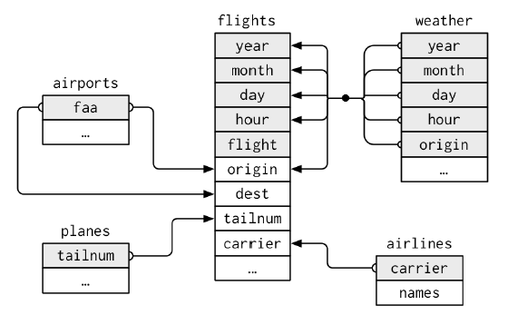

## 2.2 Exercises

1. Imagine you wanted to draw (approximately) the route each plane flies from its origin to its destination. What variables would you need? What tables would you need to combine?
- flights table : origin and dest
- airports table : longitude and latitude variables
- join flights with airports twice. The first joing adds the location of the origin airport (origin). The second join adds the location of destination airport(dest).
2. I forgot to draw the relationship between weather and air ports. What is the relationship and how should it appear in the diagram?

weather은 뉴욕의 세개의 공항의 데이터(origin로 식별)를 지원하고 airport에 그 공항들(faa로 식별)의 위치 데이터가 있다.

3. weather only contains information for the origin (NYC) airports. If it contained weather records for all airports in the USA, what additional relation would it define with flights?

여기서 NYC는 뉴욕이다. year, month, day, hour, origin in weather would be matched to year, month, day, hour, dest in flight. flight의 날짜, 시간은 출발 시간임에 유의하자.

4. We know that some days of the year are “special,” and fewer people than usual fly on them. How might you represent that data as a data frame? What would be the primary keys of that table? How would it connect to the existing tables?

## 2.3 Keys

테이블 쌍을 연결해주는 변수들을 key라고 부른다. key는 관측치를 유일하게 식별하는 변수이다.

두 가지 타입의 key :

- A *primary key*은 테이블의 관측치를 유일하게 식별한다. planes$tailnum은 primary key
- A *foreign key*는 다른 테이블에서 유일하게 식별한다. flgiths$tailnum은 foreign key

primary key를 찾았다면, 각 관측치를 유이랗게 식별하는지 확인해보는 것은 좋은 습관이다.

```r
planes %>%
  count(tailnum) %>%
  filter(n > 1)
```

```
## # A tibble: 0 x 2
## # ... with 2 variables: tailnum <chr>, n <int>
```

```r
# 왜 n = 2가 존재하는거지..
weather %>%
  count(year, month, day, hour, origin) %>%
  filter(n > 1)
```

```
## # A tibble: 3 x 6
##    year month   day  hour origin     n
##   <dbl> <dbl> <int> <int> <chr>  <int>
## 1  2013    11     3     1 EWR        2
## 2  2013    11     3     1 JFK        2
## 3  2013    11     3     1 LGA        2
```

때때로 명백한 primary key가 존재하지 않을 수 있다. 날짜에 항공편을 더한 것이나 tail num을 더한 것 둘 다 유일하지 않다.

```r
flights %>%
  count(year, month, day, flight) %>%
  filter(n > 1)
```

```
## # A tibble: 29,768 x 5
##     year month   day flight     n
##    <int> <int> <int>  <int> <int>
##  1  2013     1     1      1     2
##  2  2013     1     1      3     2
##  3  2013     1     1      4     2
##  4  2013     1     1     11     3
##  5  2013     1     1     15     2
##  6  2013     1     1     21     2
##  7  2013     1     1     27     4
##  8  2013     1     1     31     2
##  9  2013     1     1     32     2
## 10  2013     1     1     35     2
## # ... with 29,758 more rows
```

```r
flights %>%
  count(year, month, day, tailnum) %>%
  filter(n > 1)
```

```
## # A tibble: 64,928 x 5
##     year month   day tailnum     n
##    <int> <int> <int> <chr>   <int>
##  1  2013     1     1 N0EGMQ      2
##  2  2013     1     1 N11189      2
##  3  2013     1     1 N11536      2
##  4  2013     1     1 N11544      3
##  5  2013     1     1 N11551      2
##  6  2013     1     1 N12540      2
##  7  2013     1     1 N12567      2
##  8  2013     1     1 N13123      2
##  9  2013     1     1 N13538      3
## 10  2013     1     1 N13566      3
## # ... with 64,918 more rows
```

primary key가 부족하다면, mutate()와 row_number()를 사용하여 관측치를 쉽게 매칭시킬 수 있다. 이것을 *surrogate key*라고 한다.

primary key와 그에 대응하는 foreign key는 relation을 형성한다. relations는 전형적으로 one-to-many이다. 예를 들어, 각 항공편은 하나의 비행기를 가지지만, 각 비행기는 여러 항공편을 가진다. 다른 데이터에서는 1-to-1 관계를 볼 수도 있다. 당신은 이 것을 1-to-many 의 특별한 경우라고 생각 할 수 있다. many-to-many를 many-to-1 관계에 1-to-many 관계를 더한것으로 생각할 수 있다. 예를 들어, many-to-many 관계가 항공사와 공항에 있다.